# Rmarkdown自学笔记

### 2.4.4 表格

方式1：Markdown 语法编写表格。

| title | column1 | column2 |
| --- | --- | --- |
| row1 | 1 | 2 |
| row2 | 3 | 4 |

方式2：使用knitr包中的`kable()`函数，它接受一个数据框，返回对应的表格。

```r
library(tidyverse) # 调用tidyverse包。
dt <- iris %>% group_by(Species) %>% summarise(Sepal.Width.mean=mean(Sepal.Width), Sepal.Length.mean=mean(Sepal.Length)) # 对iris数据集分组统计后构建新数据集dt。
dt %>% knitr::kable() # 对内置数据集iris进行分组统计后用knit包kable函数输出为表格。
```

| Species | Sepal.Width.mean | Sepal.Length.mean |
| --- | --- | --- |
| setosa | 3.428 | 5.006 |
| versicolor | 2.770 | 5.936 |
| virginica | 2.974 | 6.588 |

sjPlot包绘制三线表

```r
library(sjPlot) # 调用sjPlot。
tab_df(dt) # 绘制三线表。
```

| Species | Sepal.Width.mean | Sepal.Length.mean |
| --- | --- | --- |
| setosa | 3.43 | 5.01 |
| versicolor | 2.77 | 5.94 |
| virginica | 2.97 | 6.59 |

### 2.4.5 参考文献

**1、手动添加**  
添加语法：`[<sup>参考文献的序号</sup>](#refer-anchor)`  
在正文添加以上语法，在文末尾写好参考文献标题，在标题下按序号添加相应的参考文献内容或者链接。  
如：`[参考文献的序号] 数据可视化工具目录，<https://datavizcatalogue.com/ZH/>`  
*个人认为手动添加适用于笔记类文章书写时添加参考文献。*

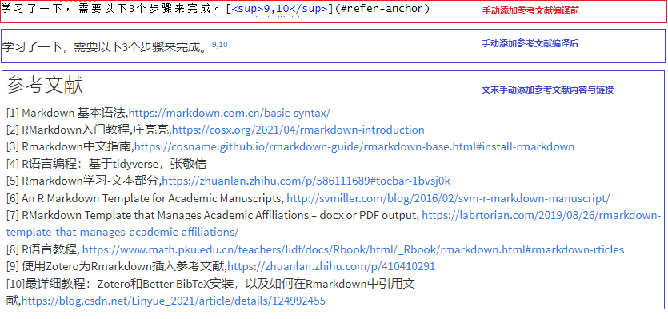

下面学习一下如何利用zotero和Rmarkdown为科技论文添加参考文献。输出格式为pdf。

**2、借助zotero添加参考文献**  
学习了一下，需要以下3个步骤来完成。<sup>9,10</sup>  
*step1：zotero中安装插件Better BibTex*  
安装此插件的目的是导出文献库，导出步骤：在zotero中选中要导出的文献库或者文献分类，鼠标右键选择导出文献库，这时会跳出导出设置界面，可选择keep updated，这样做的好处是后期文献库若有更新，导出的库也会更新，点击ok，跳出保存路径选择框，给导出的文件命名并选择保存路径后，就会导出.bib格式的文献库。注意：要想引用此文献库的参考文献，需将此文献库(.bib)与正在编辑的Rmarkdown文件(.rmd)保存在同一路径。  
*step2：Rstudio中安装rbbt包*  
在Rstudio中运行如下命令：  
`remotes::install_github("paleolimbot/rbbt")`

这样在Rstudio中就安装了zotero和Rmarkdown的联动插件。在RStudio的Addins中可以看到RBBT相关的按钮。点击Insert Zotero Citation按钮，会弹出Zotero文献的选择弹窗，选取要引用的文献后，文献自动插入Rmarkdown中。  
*step3：Rmarkdown中设置*  
在Rmarkdown头部进行如下设置：

`bibliography: myreference.bib`

bibliography用于设置引用的文献库，这里myreference.bib是从zotero中导出的自命名文献库。

`csl: field-crops-research.csl`

csl用于设置文献引用样式，这里field-crops-research.csl是在https://www.zotero.org/styles网站搜索Field Crops Research期刊样式后下载的文献样式文档。要想引用此样式，需将此文档(.csl)保存在与Rmarkdown(.rmd)文档同一目录内。

完成以上步骤后，Knit导出pdf文档即可。以下是自己演示的一个范例。

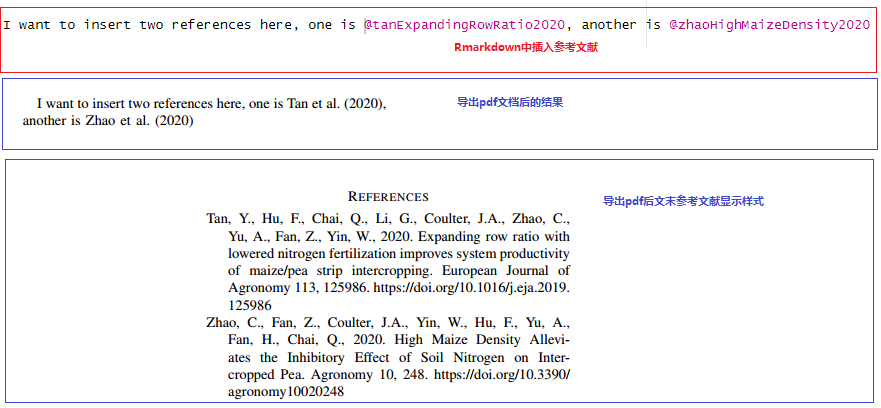

# 3 用bookdown制作图书